## Chick weights

The `ChickWeight` data set is part of the base package `datasets`. See `?ChickWeight` for details on the data. For all of the questions use `dplyr` functions with the pipe `%>%` whenever possible.

**Submission instructions**: Create a folder named `ds202_hw4`, and name the RMarkDown file including your solutions `hw4.Rmd` under this folder. For the submission, create a GitHub repository named `ds202_hw4` under your GitHub account, and push both `hw4.Rmd` and the knitted `hw4.html` before the deadline. I will assume you use the same GitHub username as for your HW3 submission. The latest version of your homework appearing on GitHub before the deadline is graded. *It is crucial to follow the exact folder structure and file names*. This homework is **due on March 4** before class.

```r
library(ggplot2)
library(dplyr)
```

1. Get a frequency breakdown of the number of chicks, their average weight and the standard deviation of the weights in each of the diets at the start of the study. Store the resulting data frame in a variable named `weight0` and print.

```r
#ChickWeight <- ChickWeight %>% mutate(Chick = as.numeric(Chick), Diet = as.factor(Diet))
weight0 <- ChickWeight %>% filter(Time == 0) %>% group_by(Diet) %>% summarize(num_chicks = n(), mean_weight = mean(weight, na.rm = TRUE), sd_weight = sd(weight, na.rm = TRUE))
weight0
```

```
## # A tibble: 4 x 4
##   Diet  num_chicks mean_weight sd_weight
##   <fct>      <int>       <dbl>     <dbl>
## 1 1             20        41.4     0.995
## 2 2             10        40.7     1.49
## 3 3             10        40.8     1.03
## 4 4             10        41       1.05
```

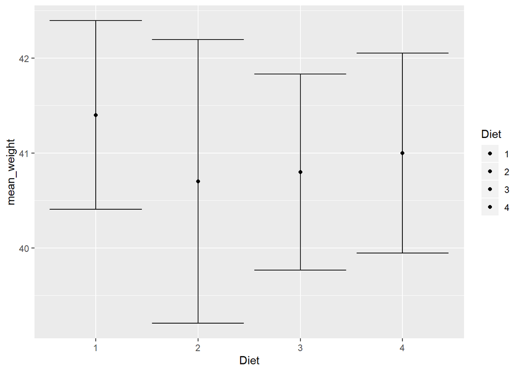

```r
ggplot(weight0, aes(x = Diet, y = mean_weight, fill = Diet)) + geom_errorbar(aes(ymin = mean_weight - sd_weight, ymax = mean_weight + sd_weight)) + geom_point()
```

2. Each chick should have twelve weight measurements. Use the `dplyr` package to identify how many measurements are there for each chick. Extract a subset of the data for all chicks with complete information, name the data set `complete`, and print the first 3 rows. (Hint: you might want to use mutate to introduce a helper variable consisting of the number of observations)

```r
ChickWeight %>% group_by(Chick) %>% summarize(n = n())
```

```
## # A tibble: 50 x 2
##    Chick     n
##    <ord> <int>
##  1 18        2
##  2 16        7
##  3 15        8
##  4 13       12
##  5 9        12
##  6 20       12
##  7 10       12
##  8 8        11
##  9 17       12
## 10 19       12
## # ... with 40 more rows
```

```r
complete <- ChickWeight %>% select_all()
complete %>% head(3)
```

```
##   weight Time Chick Diet
## 1     42    0     1    1
## 2     51    2     1    1
## 3     59    4     1    1
```

3. In the complete data set introduce a new variable that measures the current weight difference compared to day 0. Name this variable `weightgain` and print the first 3 rows of the new data frame.

```r
helper <- complete %>% filter(Time == 0) %>% mutate(baseWeight = weight) %>% select(Chick, baseWeight)

completeWGain <- complete %>% left_join(helper, by = 'Chick') %>% mutate(weightgain = weight - baseWeight) %>% select(-c(baseWeight))
completeWGain %>% head(3)
```

```
##   weight Time Chick Diet weightgain
## 1     42    0     1    1          0
## 2     51    2     1    1          9
## 3     59    4     1    1         17
```

4. Use `{ggplot2}` to create side-by-side boxplots of `weightgain` by `Diet` for day 21. Change the order of the categories in the Diet variable such that the boxplots are ordered by median `weightgain`, and the lower limit of the y axis should be 0. Describe the relationship in 2-3 sentences.

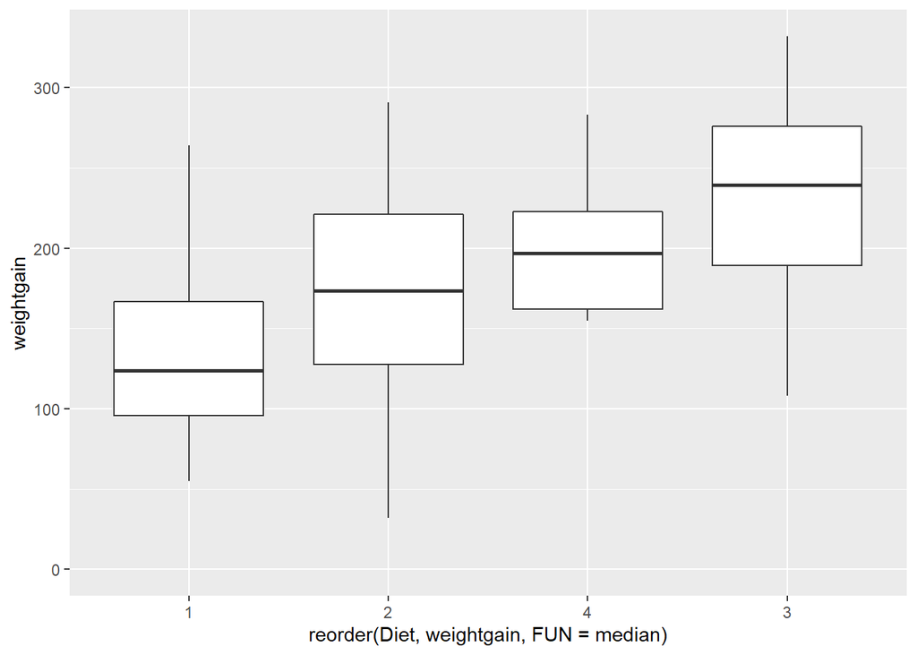

```r
ggplot(completeWGain %>% filter(Time == 21), aes(x = reorder(Diet, weightgain, FUN = median),  y = weightgain)) + geom_boxplot() + expand_limits(y = 0)
```

Various diets have varying degrees of weight gain and differing standarx deviation. For instance, diet 4 has the most narrow spread and 2 has the widest. Additionally, 3 has the highest median weight gain and 1 has the least.

5. Answer each of the following questions using numerical and graphical summary. Also explain what you found: (a) Which chick gained the most weight and which gained the least weight? (b) What diets were they on?

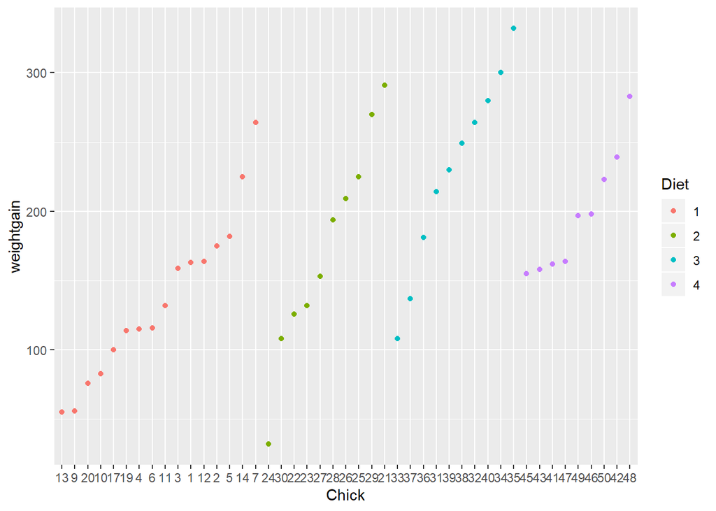

```r
ggplot(completeWGain %>% filter(Time == 21), aes(y = weightgain, x = Chick, color = Diet)) + geom_point()
```

```r
completeWGain %>% filter(Time == max(Time)) %>% arrange(desc(weightgain)) %>% head(1)
```

```
##   weight Time Chick Diet weightgain
## 1    373   21    35    3        332
```

Chick 35 gained the most weight. This chick was on diet 3.

```r
completeWGain %>% filter(Time == max(Time)) %>% arrange(weightgain) %>% head(1)
```

```
##   weight Time Chick Diet weightgain
## 1     74   21    24    2         32
```

Chick 24 gained the least weight. This chick was on diet 2.

6. For the chicks with the least and the most weight at time 0, plot their growth trajectories over time.

```r
extremes <- completeWGain %>% filter(Time == 0, weight == 43) %>% select(Chick) %>% full_join(completeWGain %>% filter(Time == 0, weight == 39) %>% select(Chick))
```

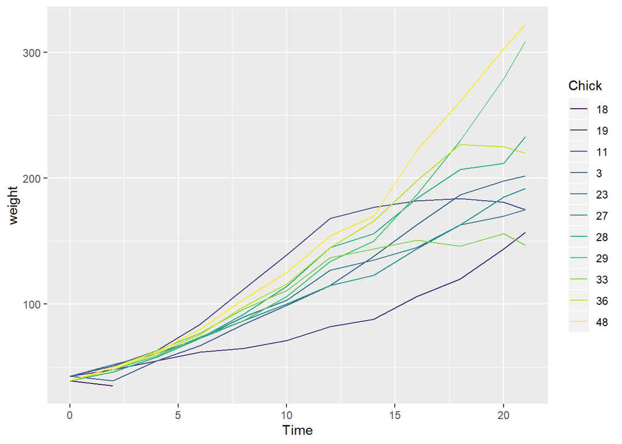

```r
completeExtremes <- complete %>% inner_join(extremes, by = 'Chick')
avgWeightsbyTime <- complete %>% group_by(Time) %>% summarize(avgWeight = mean(weight))

plot1 <- ggplot(completeExtremes %>% inner_join(avgWeightsbyTime, by = "Time"), aes(x = Time, y = weight, by = Chick, color = Chick)) + geom_line()
plot1
```

7. Add to the previous plot the average growth trajectory for all chicks (calculated as the mean weight for each chick at each time). How do the trajectories compare?

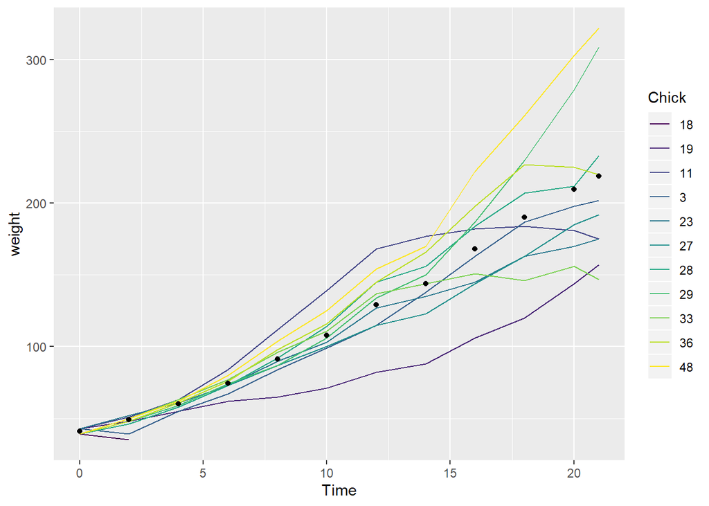

```r
plot1 + geom_point(aes(x = Time, y = avgWeight), color = "black")
```

Very similar trajectories, despite individual variation.

8. What else do you find interesting in the dataset? Show your exploratory analysis.

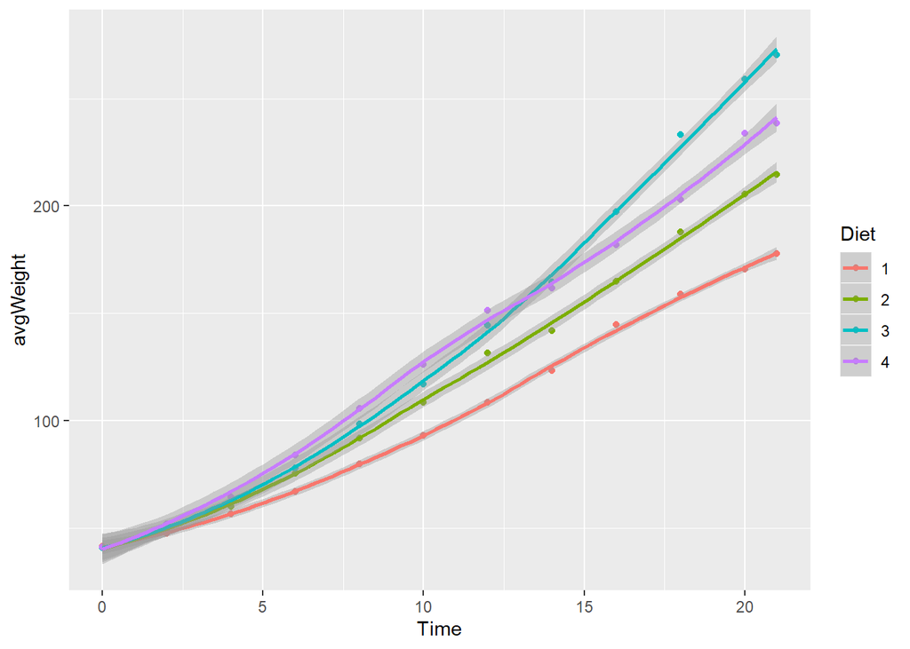

```r
ggplot(complete %>% group_by(Diet, Time) %>% summarize(avgWeight = mean(weight)), aes(x = Time, y = avgWeight, by = Diet, color = Diet)) + geom_point() + geom_smooth()
```

This plot shows all of the average weights at each time by diet. From this we can see how the weights are impacted by diet over time. For example, all chicks start out at very similar weights however diets 1, 2, and 4 have similar relationships with the final average weight in increasing order. Diet 3 stands out by starting with lower average weight than diet 4 until some where around a time of 13. It then goes on to increase almost exponentially to end with the highest average weight.

Note: your submission is supposed to be fully reproducible, i.e. the TA and I will ‘knit’ your submission in RStudio.